# Solution: testing hypothesis 2 with the data on dormice

Radchuk Viktoriia

2022-1-5

# Hypothesis

- No effect of temperature on metabolic rate of normothermic individuals is expected because they should be able to thermoregulate

# Read in and prepare the data

```r
df$Log_MR <- log(df$MR_h)
df$Tamb2 <- df$Tamb^2
df$Y <- 2009
df$Y[df$Year %in% c(2011, 2012)] <- 2011
df$Y <- as.factor(df$Y)
df$ID <- as.factor(df$ID)
```

```r
## just use the subset of the data with the individuals in state == 1 (aroused)
aroused <- df[df$state == 1, ]

nrow(aroused)  ### 2765
```

```
## [1] 2765
```

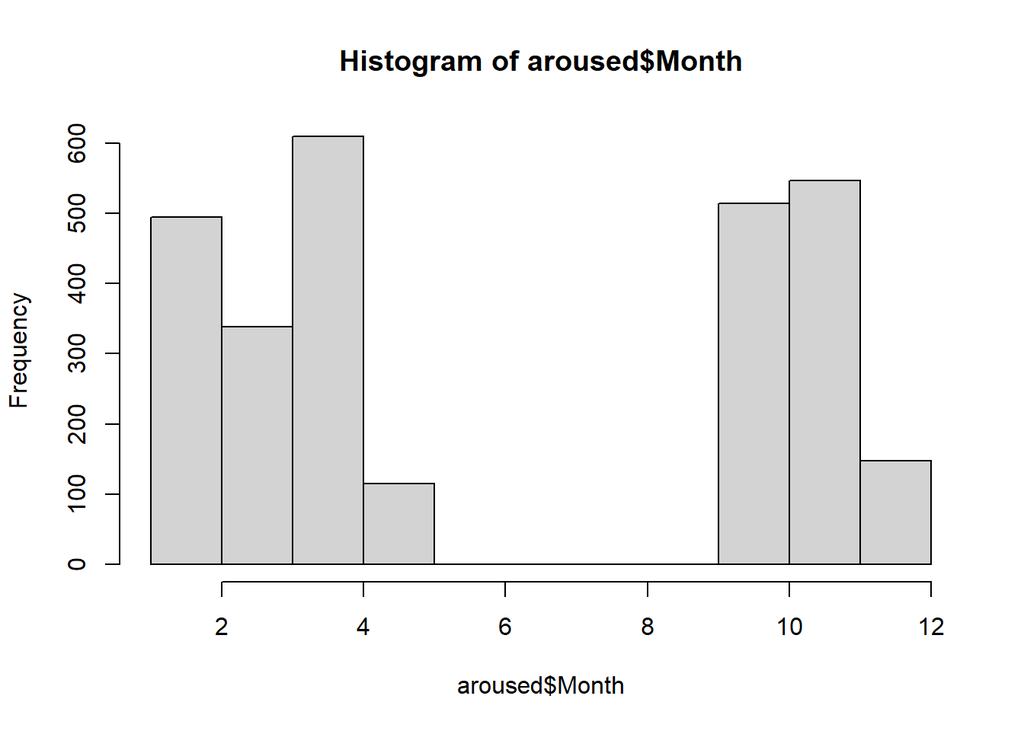

```r
hist(aroused$Month)
```

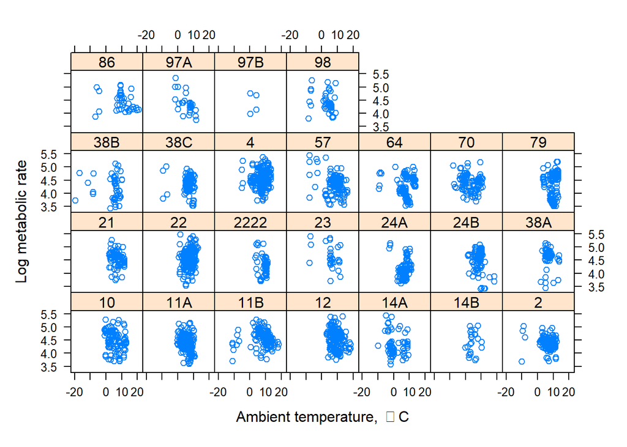

```r
xyplot(Log_MR ~ Tamb|ID, data = aroused, xlab = expression('Ambient temperature, ' ~degree~C), ylab = 'Log metabolic rate')
```

```r
# exclude missing values
aroused <- aroused[!is.na(aroused$Log_MR), ]
```

## Mixed-effects model with ID as random intercept

I will use glmmTMB here but you may have chosen a different R package

```r
modRandID_arous <- glmmTMB(Log_MR ~ Tamb  + Y + (1|ID),
                        data = aroused)
summary(modRandID_arous)
```

```
##  Family: gaussian  ( identity )
## Formula:          Log_MR ~ Tamb + Y + (1 | ID)
## Data: aroused
##
##      AIC      BIC   logLik deviance df.resid
##   1763.5   1792.9   -876.7   1753.5     2641
##
## Random effects:
##
## Conditional model:
##  Groups   Name        Variance Std.Dev.
##  ID       (Intercept) 0.01559  0.1248
##  Residual             0.11090  0.3330
## Number of obs: 2646, groups:  ID, 25
##
## Dispersion estimate for gaussian family (sigma^2): 0.111
##
## Conditional model:
##              Estimate Std. Error z value Pr(>|z|)
## (Intercept)  4.461038   0.038921  114.62  < 2e-16 ***
## Tamb        -0.009561   0.001750   -5.46 4.63e-08 ***
## Y2011        0.038139   0.053063    0.72    0.472
## ---
## Signif. codes:  0 '***' 0.001 '**' 0.01 '*' 0.05 '.' 0.1 ' ' 1
```

## Model diagnostics

Using DHARMa directly.

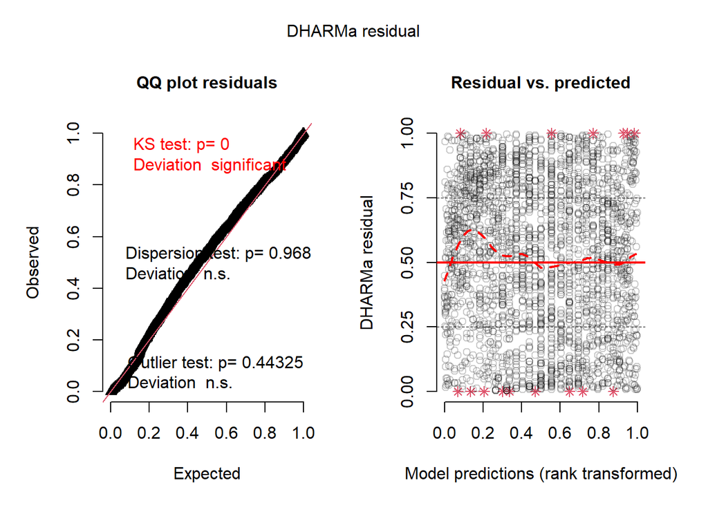

```r
sim <- simulateResiduals(modRandID_arous, plot = T)
```

```r
testUniformity(sim, plot = F)
```

```
##
##  Asymptotic one-sample Kolmogorov-Smirnov test
##
## data:  simulationOutput$scaledResiduals
## D = 0.055997, p-value = 1.243e-07
## alternative hypothesis: two-sided
```

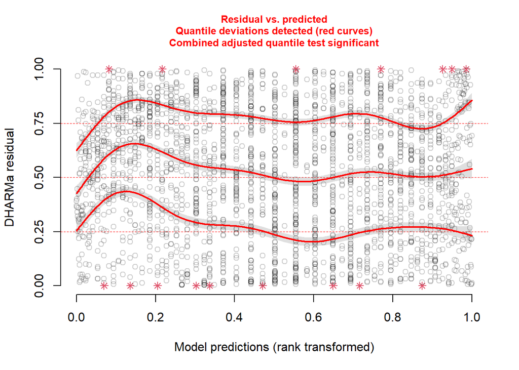

```
##
##  Test for location of quantiles via qgam
##
## data:  simulationOutput
## p-value < 2.2e-16
## alternative hypothesis: both
```

```r
testQuantiles(sim, plot = T)
```

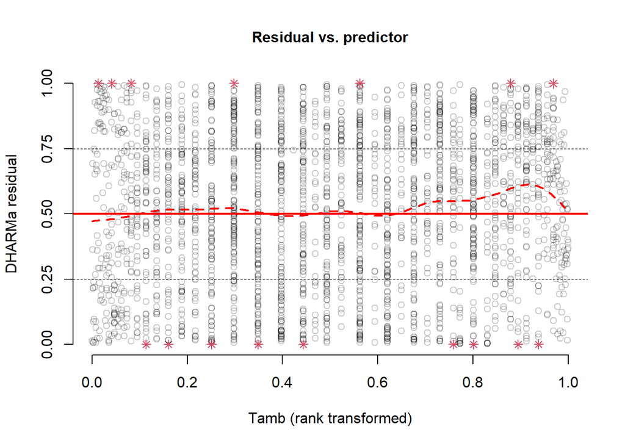

```r
# plot residuals vs our predictors
plotResiduals(sim, form = aroused$Tamb)
```

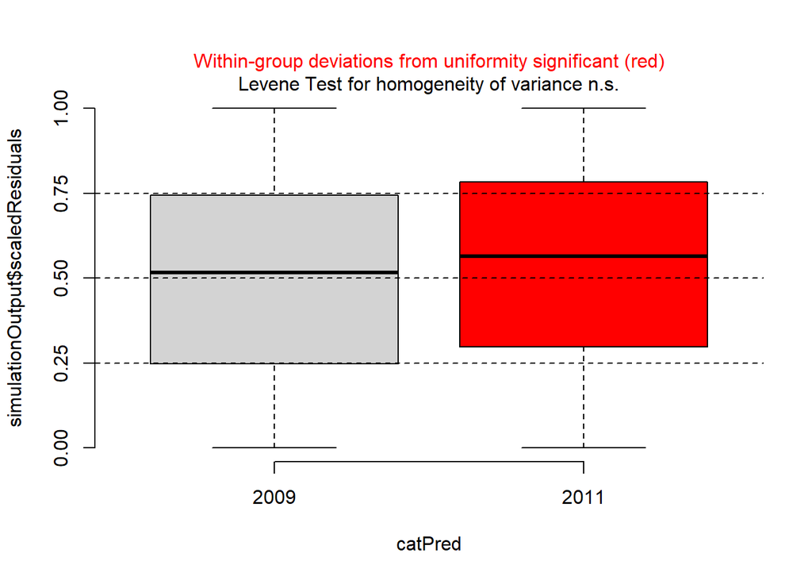

```r
plotResiduals(sim, form = aroused$Y)
```

How do we interpret these plots?

Let us test for temporal autocorrelation, since the measurements were taken over time for each individual.

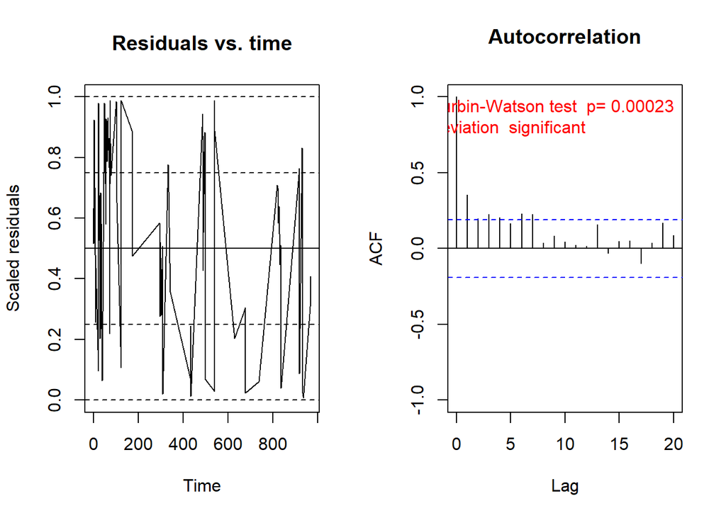

```
##
##  Durbin-Watson test
##
## data:  simulationOutput$scaledResiduals ~ 1
## DW = 1.2884, p-value = 0.0002322
## alternative hypothesis: true autocorrelation is not 0
```

```r
sim_ID10 <- recalculateResiduals(sim, sel = aroused$ID == 10)
testTemporalAutocorrelation(sim_ID10, time = aroused$Timecon[aroused$ID == '10'])
```

Using the same function we used in the lecture to test temporal autocorrelation for each individual in the dataset.

```r
levels(aroused$ID)
```

```
##  [1] "10"   "11A"  "11B"  "12"   "14A"  "14B"  "2"    "21"   "22"   "2222"
## [11] "23"   "24A"  "24B"  "38A"  "38B"  "38C"  "4"    "57"   "64"   "70"
## [21] "79"   "86"   "97A"  "97B"  "98"
```

```r
fun_autocor(sim, aroused, ID = '10')
```

```
## [[1]]
##
##  Durbin-Watson test
##
## data:  simulationOutput$scaledResiduals ~ 1
## DW = 1.2884, p-value = 0.0002322
## alternative hypothesis: true autocorrelation is not 0
##
##
## [[2]]
##       DurbW            p ID
## DW 1.288368 0.0002322403 10
```

### Test autocorrelation in all studies

```r
dat_autoc <- data.frame(DurbW =numeric(), p = numeric())
dat_autoc <- rbind(dat_autoc, fun_autocor(sim, aroused, 10)[[2]])
for(i in unique(aroused$ID)[-1]){
  dat_autoc <- rbind(dat_autoc, fun_autocor(sim, aroused, ID = i)[[2]])
}

length(levels(aroused$ID))
```

```
## [1] 25
```

```r
dat_autoc$sign <- ifelse(dat_autoc$p < 0.05,'Yes','No')
sum(dat_autoc$sign == 'Yes')
```

```
## [1] 19
```

```r
sum(dat_autoc$sign == 'Yes')/length(levels(aroused$ID))
```

```
## [1] 0.76
```

So, temporal autocorrelation is an issue here.

## Mixed-effects model accounting for temporal autocorrelation

```r
aroused$Time_fac <- as.factor(aroused$Timecon)
modRandID_arousAR <- glmmTMB(Log_MR ~ Tamb + Y + (1|ID) +
                             ar1(Time_fac - 1|ID),
                        data = aroused)
summary(modRandID_arousAR)
```

```
##  Family: gaussian  ( identity )
## Formula:          Log_MR ~ Tamb + Y + (1 | ID) + ar1(Time_fac - 1 | ID)
## Data: aroused
##
##      AIC      BIC   logLik deviance df.resid
##    841.0    882.1   -413.5    827.0     2639
##
## Random effects:
##
## Conditional model:
##  Groups   Name        Variance Std.Dev. Corr
##  ID       (Intercept) 0.002845 0.05333
##  ID.1     Time_fac1   0.069423 0.26348  0.97 (ar1)
##  Residual             0.058269 0.24139
## Number of obs: 2646, groups:  ID, 25
##
## Dispersion estimate for gaussian family (sigma^2): 0.0583
##
## Conditional model:
##              Estimate Std. Error z value Pr(>|z|)
## (Intercept)  4.476027   0.039740  112.63  < 2e-16 ***
## Tamb        -0.011468   0.002976   -3.85 0.000116 ***
## Y2011        0.039507   0.049699    0.79 0.426660
## ---
## Signif. codes:  0 '***' 0.001 '**' 0.01 '*' 0.05 '.' 0.1 ' ' 1
```

## Model diagnostics

Remember we need to rotate the residuals otherwise there is no point looking at the diagnostics (the autocorrealtion will still be there in the residual structure)

This takes long time, run it in your free time.

```r
## Do not run
simAR1_rot <- simulateResiduals(modRandID_arousAR, plot = T, rotation = 'estimated')
testUniformity(simAR1_rot, plot = F)
testQuantiles(simAR1_rot, plot = T)
# plot residuals vs our predictors
plotResiduals(simAR1_rot, form = aroused$Tamb)
plotResiduals(simAR1_rot, form = aroused$Y)
```

How do we interpret these plots?

# Model inference

Interpreting the results of the model (assuming that the model diagnostics were fine, first make sure to run the diagnostics in full!).  
We use LRT to test the significance of the linear effect of temperature on metabolic rate in normothermic individuals.

```r
modRandID_arous_noT <- glmmTMB(Log_MR ~ Y + (1|ID) +
                                 ar1(Time_fac - 1|ID),
                        data = aroused)
summary(modRandID_arous_noT)
```

```
##  Family: gaussian  ( identity )
## Formula:          Log_MR ~ Y + (1 | ID) + ar1(Time_fac - 1 | ID)
## Data: aroused
##
##      AIC      BIC   logLik deviance df.resid
##    853.4    888.7   -420.7    841.4     2640
##
## Random effects:
##
## Conditional model:
##  Groups   Name        Variance Std.Dev. Corr
##  ID       (Intercept) 0.001592 0.0399
##  ID.1     Time_fac1   0.073571 0.2712   0.97 (ar1)
##  Residual             0.057334 0.2394
## Number of obs: 2646, groups:  ID, 25
##
## Dispersion estimate for gaussian family (sigma^2): 0.0573
##
## Conditional model:
##             Estimate Std. Error z value Pr(>|z|)
## (Intercept)  4.42503    0.03620  122.22   <2e-16 ***
## Y2011        0.01570    0.04726    0.33     0.74
## ---
## Signif. codes:  0 '***' 0.001 '**' 0.01 '*' 0.05 '.' 0.1 ' ' 1
```

```r
## pay attention: we by default fitted models with ML so we can run LRT to test the significance of the fixed effect

anova(modRandID_arous_noT, modRandID_arousAR)  ## significant effect
```

```
## Data: aroused
## Models:
## modRandID_arous_noT: Log_MR ~ Y + (1 | ID) + ar1(Time_fac - 1 | ID), zi=~0, disp=~1
## modRandID_arousAR: Log_MR ~ Tamb + Y + (1 | ID) + ar1(Time_fac - 1 | ID), zi=~0, disp=~1
##                     Df    AIC    BIC  logLik deviance  Chisq Chi Df Pr(>Chisq)
## modRandID_arous_noT  6 853.39 888.67 -420.69   841.39
## modRandID_arousAR    7 840.98 882.14 -413.49   826.98 14.414      1  0.0001467
##
## modRandID_arous_noT
## modRandID_arousAR   ***
## ---
## Signif. codes:  0 '***' 0.001 '**' 0.01 '*' 0.05 '.' 0.1 ' ' 1
```

Do we find support for our hypothesis?

# Plot predictions

```r
min(aroused$Tamb)
```

```
## [1] -19.5
```

```r
new_dat <- expand.grid('ID' = unique(aroused$ID),
                       'Y' = unique(aroused$Y),
                       'Tamb' = seq(from = min(aroused$Tamb), to =
                                    max(aroused$Tamb), length.out = 20))

head(new_dat)
```

```
##    ID    Y  Tamb
## 1  10 2011 -19.5
## 2 11A 2011 -19.5
## 3 11B 2011 -19.5
## 4  12 2011 -19.5
## 5 14A 2011 -19.5
## 6 14B 2011 -19.5
```

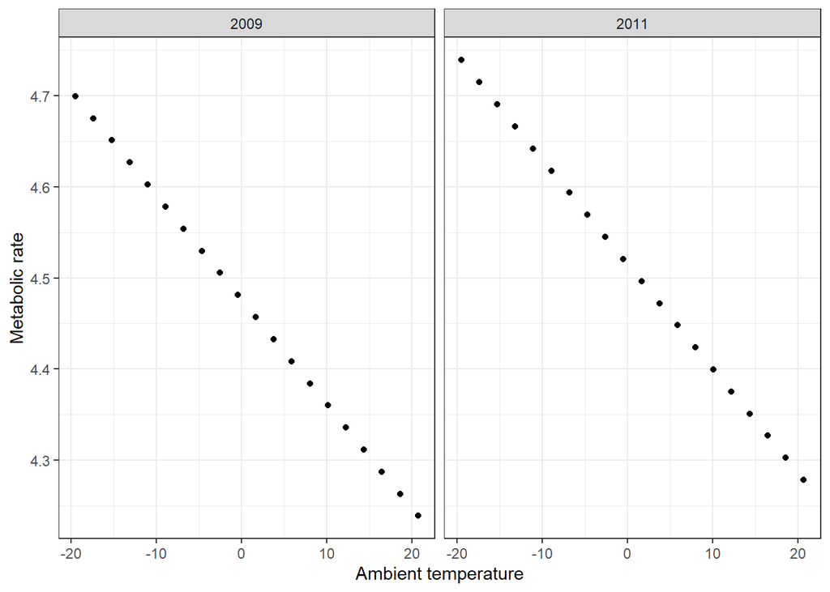

```r
new_dat$Time_fac <- as.factor(rep('10', nrow(new_dat)))  ## keeping just to one time point
new_dat$pred_fixTMB <- predict(modRandID_arousAR, newdata = new_dat, re.form = NA, type = 'response')

ggplot(data = new_dat, aes(x = Tamb, y = pred_fixTMB)) +
  geom_point() + theme_bw() +
  facet_grid(cols = vars(Y)) +
  xlab('Ambient temperature') + ylab('Metabolic rate')
```

Adding confidence intervals to the plots

```r
new_dat$pre_SE_fixTMB <- predict(modRandID_arousAR, newdata = new_dat, re.form = NA, se.fit = TRUE, type = 'response')$se.fit
new_dat$pred_upper_fix <- new_dat$pred_fixTMB + qnorm(0.975)*new_dat$pre_SE_fixTMB
new_dat$pred_lower_fix <- new_dat$pred_fixTMB - qnorm(0.975)*new_dat$pre_SE_fixTMB
head(new_dat)
```

```
##    ID    Y  Tamb Time_fac pred_fixTMB pre_SE_fixTMB pred_upper_fix
## 1  10 2011 -19.5       10    4.739161    0.08381881       4.903443
## 2 11A 2011 -19.5       10    4.739161    0.08381881       4.903443
## 3 11B 2011 -19.5       10    4.739161    0.08381881       4.903443
## 4  12 2011 -19.5       10    4.739161    0.08381881       4.903443
## 5 14A 2011 -19.5       10    4.739161    0.08381881       4.903443
## 6 14B 2011 -19.5       10    4.739161    0.08381881       4.903443
##   pred_lower_fix
## 1       4.574879
## 2       4.574879
## 3       4.574879
## 4       4.574879
## 5       4.574879
## 6       4.574879
```

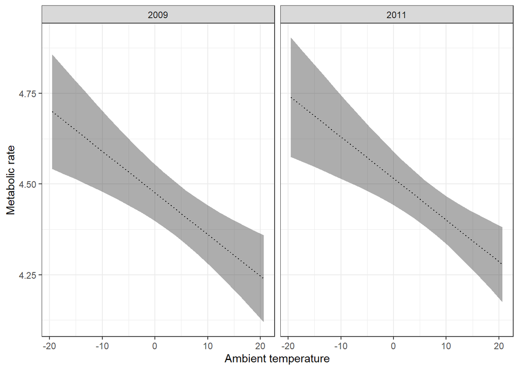

```r
ggplot(data = new_dat, aes(x = Tamb, y = pred_fixTMB)) +
  theme_bw() + facet_grid(cols = vars(Y)) +
  geom_ribbon(data = new_dat, aes(x = Tamb, ymin = pred_lower_fix, ymax = pred_upper_fix), alpha = 0.4) +
  geom_line(lty  = 3) +
    xlab('Ambient temperature') + ylab('Metabolic rate')
```